# Part II - PISA 2018 Database

## Investigation Overview

In this explanatory section, I will discuss the key factors affecting students' overall literacy.

## Dataset Overview and Executive Summary

The 2018 PISA School Dataset was constructed and organized into SAS and SPSS files. PISA, an acronym for "Programme for International Student Assessment," is a triennial assessment covering reading, mathematics, and science literacy that is taken by 15 year-old students. In 2018, PISA involved 79 countries and 600,000+ students worldwide.

The original file 'CY7_MS_CMB_STU_QQQ.sav' downloaded from webite https://www.oecd.org/pisa/data/2018database/ is too big that my computer can read. So, I extract useful columns that are used in this project.

Following is a summary of findings that my visualizations will support.

1. The Grade Distribution
2. The Overall literacy
3. The Country where has the highest Overall Literacy
4. Relationship between Internet connection and Overall Literacy
5. Highest Parental Occupational Status affect Overall Literacy and Class Repeated
6. Internet Connection affects Class Repeated and Overall Literacy

```python
# import all packages and set plots to be embedded inline
import numpy as np
import pandas as pd
import matplotlib.pyplot as plt
import seaborn as sb

# suppress warnings from final output
import warnings
warnings.simplefilter("ignore")
```

```python
# load in the dataset into a pandas dataframe
df_pisa = pd.read_csv('pisa18_clean.csv')
```

```python
df_pisa.head()
```

|  | Unnamed: 0 | Country | OECD | Student Grade | Grade | PV1MATH | PV2MATH | PV3MATH | PV4MATH | PV5MATH | ... | Mother_Immigrant | Highest_edu_level_parents | Highest_parental_occu_status | Highest_parental_edu_years | Class_repeated | Computer_use_mins | Avg_Math | Avg_Scientific | Avg_Reading | Overall_Literacy |
| --- | --- | --- | --- | --- | --- | --- | --- | --- | --- | --- | --- | --- | --- | --- | --- | --- | --- | --- | --- | --- | --- |
| 0 | 0 | Albania | No | Grade 10 | 0.0 | 490.187 | 463.503 | 422.039 | 420.998 | 465.602 | ... | Not checked | ISCED 5A, 6 | 81.40 | 16.0 | Did not repeat a grade | 1395.0 | 452.4658 | 425.1170 | 371.7800 | 416.454267 |
| 1 | 1 | Albania | No | Grade 10 | 0.0 | 462.464 | 428.730 | 476.759 | 474.432 | 583.114 | ... | Not checked | ISCED 2 | 65.01 | 10.0 | Did not repeat a grade | 1665.0 | 485.0998 | 432.8706 | 437.7324 | 451.900933 |
| 2 | 2 | Albania | No | Grade 10 | 0.0 | 406.949 | 428.135 | 445.234 | 415.690 | 471.794 | ... | Not checked | ISCED 2 | 32.20 | 10.0 | Did not repeat a grade | NaN | 433.5604 | 410.1926 | 341.1354 | 394.962800 |
| 3 | 3 | Albania | No | Grade 10 | 0.0 | 482.501 | 409.060 | 437.119 | 436.515 | 419.955 | ... | Not checked | ISCED 2 | 17.00 | 10.0 | Did not repeat a grade | 1395.0 | 437.0300 | 454.9340 | 404.0386 | 432.000867 |
| 4 | 4 | Albania | No | Grade 10 | 0.0 | 459.804 | 520.383 | 462.507 | 472.385 | 494.014 | ... | Not checked | ISCED 3A, ISCED 4 | 16.36 | 12.0 | Did not repeat a grade | NaN | 481.8186 | 389.2232 | 344.4034 | 405.148400 |

5 rows × 38 columns

## Visualization 1

#### How is Grade Distribution?

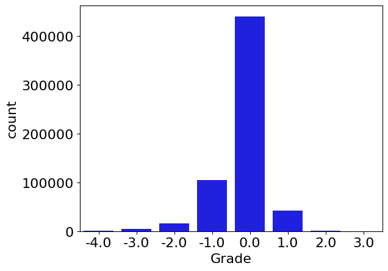

```python
sb.countplot(data=df_pisa, x='Grade', color='blue')
```

As we can see, there are no outliers as the data is tidy. The data seems normally distributed with the peak at 0.0 interval.

#### How is the Overall literacy of students?

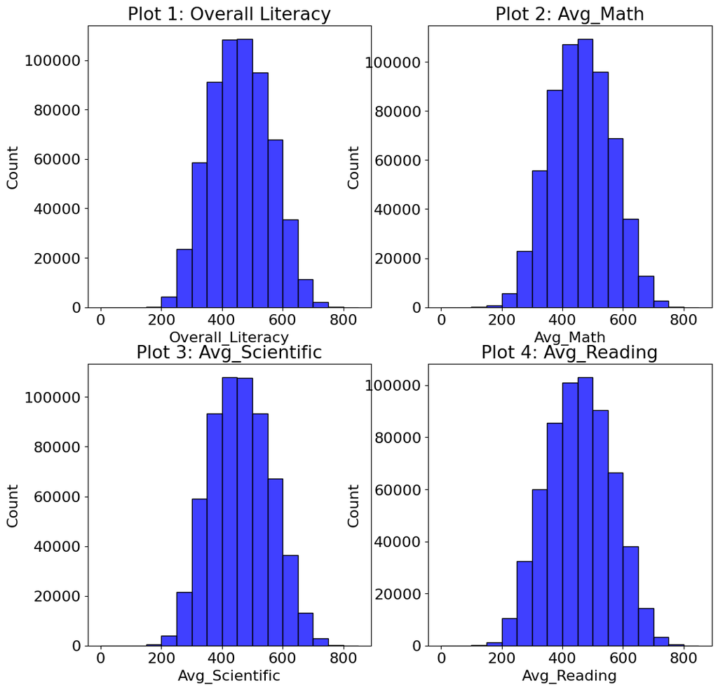

```python
fig, ax = plt.subplots(2,2, figsize=(12, 12))
bin_edges = np.arange(0,df_pisa.Overall_Literacy.max()+ 50,50)
sb.histplot(data=df_pisa, x='Overall_Literacy', bins= bin_edges, color='blue', ax=ax[0][0]);
ax[0][0].title.set_text('Plot 1: Overall Literacy')

bin_edges = np.arange(0,df_pisa.Avg_Math.max()+ 50,50)
sb.histplot(data=df_pisa, x='Avg_Math', bins= bin_edges, color='blue', ax=ax[0][1]);
ax[0][1].title.set_text('Plot 2: Avg_Math')

bin_edges = np.arange(0,df_pisa.Avg_Scientific.max()+ 50,50)
sb.histplot(data=df_pisa, x='Avg_Scientific', bins= bin_edges, color='blue', ax=ax[1][0]);
ax[1][0].title.set_text('Plot 3: Avg_Scientific')

bin_edges = np.arange(0,df_pisa.Avg_Reading.max()+ 50,50)
sb.histplot(data=df_pisa, x='Avg_Reading', bins= bin_edges, color='blue', ax=ax[1][1]);
ax[1][1].title.set_text('Plot 4: Avg_Reading')
```

In general, the average score is around 500 in all Maths, Science and reading.

#### How much time do students use computer?

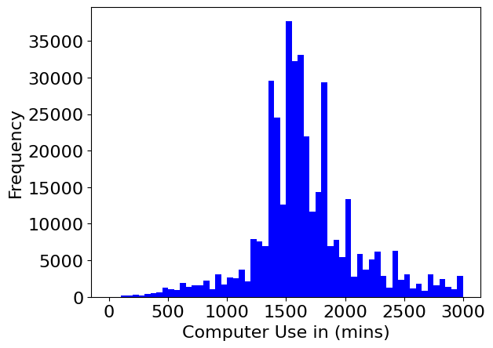

```python
bin_edges = np.arange(0,df_pisa.Computer_use_mins.max()+ 50,50)
plt.hist(data=df_pisa, x='Computer_use_mins', bins= bin_edges, color='blue');
plt.ylabel('Frequency');
plt.xlabel('Computer Use in (mins)');
```

In general, the time of using computer at home is around 1500 minutes.

## Visualization 2

#### Top 10 Countries have the highest Overall Literacy

[output not shown]

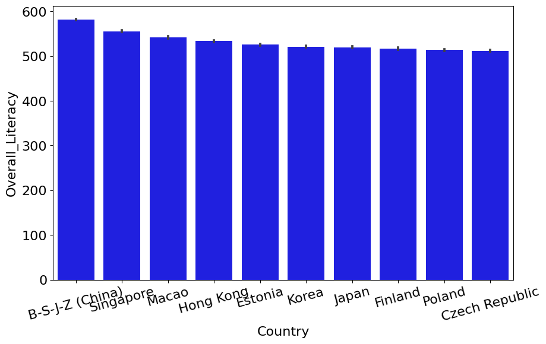

```python
plt.figure(figsize=(10,6))
result = df_pisa.groupby(["Country"])['Overall_Literacy'].aggregate(np.mean).reset_index().sort_values('Overall_Literacy', ascending= False)
sb.barplot(y='Overall_Literacy', x="Country", data=df_pisa, order=result['Country'].head(10), color='blue');
plt.xticks(rotation =15)
```

#### Relationship between Internet_Connection and Overall Literacy

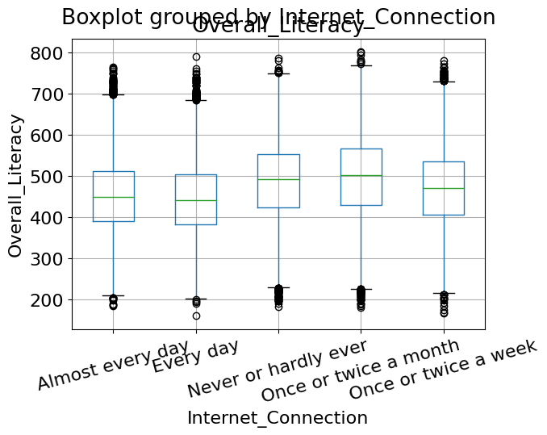

```python
df_pisa.boxplot(column = 'Overall_Literacy', by = 'Internet_Connection')
plt.xticks(rotation =15)
plt.xlabel('Internet_Connection')
plt.ylabel('Overall_Literacy')
```

We can see that, the Overall_Literacy is affected by the internet connection. The Overall_Literacy is highest at student group that they use once or twice a month and lowest at student group that they use everyday.

### Relationship between Grade and Overall Literacy

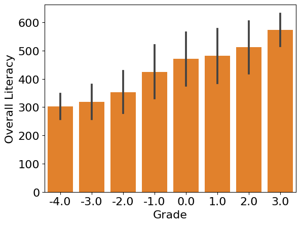

```python
base_color = sb.color_palette()[1]
sb.barplot(data=df_pisa, x='Grade', y='Overall_Literacy', color=base_color, ci='sd')
plt.xlabel('Grade');
plt.ylabel('Overall Literacy');
```

The variables Grade measured on a scale of -4.0 to 3.0 and Overall Literacy are analyzed. There is a strong positive correlation between the 2 factors. Scatter plot was not used as the plot of choice due to the discrete yet continuous nature of the Grade factor.

## Visualization 3

#### Highest Parental Occupational Status vs Overall Literacy and Class Repeated

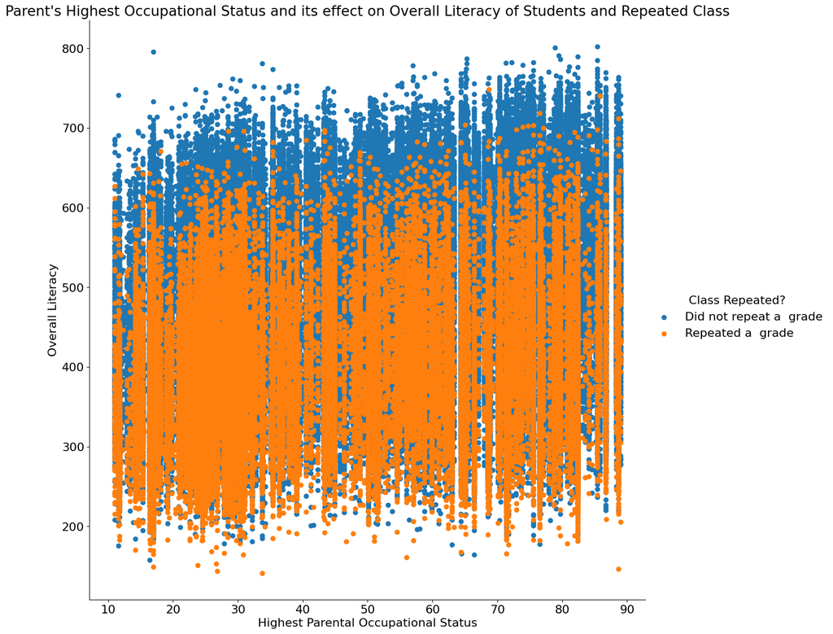

```python
g = sb.FacetGrid(data = df_pisa, hue = 'Class_repeated', height = 12)
g.map(plt.scatter, 'Highest_parental_occu_status', 'Overall_Literacy', alpha=1)
plt.title("Parent's Highest Occupational Status and its effect on Overall Literacy of Students and Repeated Class")
plt.xlabel('Highest Parental Occupational Status')
plt.ylabel('Overall Literacy')
g.add_legend(title ='Class Repeated?');
plt.rcParams.update({'font.size': 16});
```

As the Parents' occupational status increase so does the student's overall literacy, with that less and less students have repeated a class. The right side of the plot has majority of students who did not repeat a class whereas, as the parents' occupational status decrease so does the student's overall literacy, with that more and more students repeated a grade.

#### Highest Parental Occupational Status affects Overall Literacy and Grade

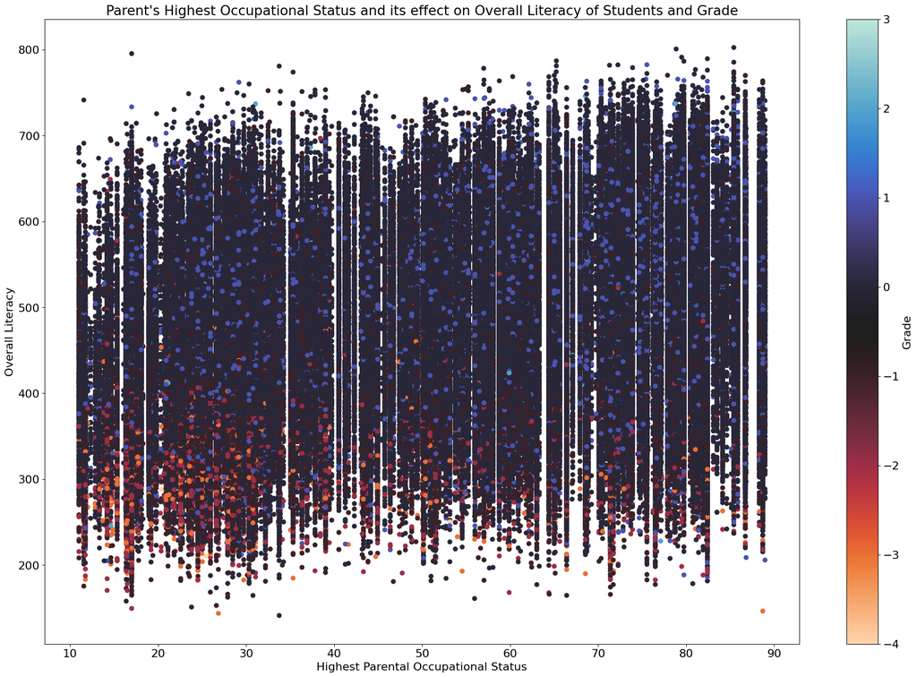

```python
plt.figure(figsize = [24, 16])
plt.scatter(data = df_pisa, x = 'Highest_parental_occu_status', y = 'Overall_Literacy', c = 'Grade',
            cmap = 'icefire_r', alpha=1)
plt.title("Parent's Highest Occupational Status and its effect on Overall Literacy of Students and Grade")
plt.xlabel('Highest Parental Occupational Status')
plt.ylabel('Overall Literacy')
plt.colorbar(label = 'Grade');
```

We can see that the student's overall literacy increase as the Parents' occupational status increase. The right side of the plot has majority of students who are in the country’s modal grade if not above the modal grade. Whereas, as the parents' occupational status decrease so does the student's overall literacy, with that more and more students are below the modal grade.

#### Internet Connection affects Class Repeated and Overall Literacy

[figure not shown]

```python
g = sb.FacetGrid(data = df_pisa, col = 'Internet_Connection', col_wrap=2, height = 6)
g.map(sb.boxplot, 'Class_repeated', 'Overall_Literacy', color='darkred');
g.axes[0].set_title("No");
g.axes[1].set_title("Yes, but I don't use it");
g.axes[2].set_title("Yes, and I use it");
g.axes[3].set_title("Once or twice a month");
g.axes[4].set_title("Once or twice a week");
```